# Cancer Mortality in Children Project

Luke Austin

2023-10-13

**Exploration of Cancer Mortality Rates among Children using ggplot2 in R**

Luke Austin

10/14/2023

**Introduction**

This report is focused on using data visualization methods from the R package “ggplot2” to interpret data related to cancer mortality in children in the United States. I chose this data due to my personal interest and background in the field of biomedical science, my interest in cancer research, and the presence and impact of cancer in today’s world. This dataset was downloaded as a text file from the CDC Wonder database and converted into a CSV file. The data contains factors such as region, year, age group, sex (male or female), and total number of deaths. The regions are divided into the standard four regions of the United States: Northeast, Midwest, West, and South. The years of the dataset are all years from 2010-2020, so the data is relatively modern, making it even more relevant. The “Age Group” category divides the children into four age groups: 1-4 years, 5-9 years, 10-14 years, and 15-19 years.

The scientific motivation for analyzing this dataset is to obtain a better understanding of how cancer deaths in children have changed over time and the overall prevalence of cancer deaths based on various demographic factors. Millions of dollars in funding goes to scientists each year for cancer research, so we might expect a decline in the number of deaths over time. We hope to verify that with this data. In addition, we seek to understand if cancer deaths are more frequent based on factors such as age, region, and sex (also called gender throughout the study). We might expect that deaths do not vary across region or gender, and if they do, further research or evaluation may be required. As children age, it’s possible they may be more likely to die of cancer due to a longer lifespan of potential exposure. In this study, we hope to evaluate all of this, interpreting and deciphering these relationships using data visualization methods. This will be done in R using the package “ggplot2”.

**Outcomes and Discussion**

The first relationship examined in this study is to see if there is any variation in cancer deaths among children over time based on region. This was evaluated with a scatterplot and lines fit for each region, as well as an overall trendline of the data, as shown below in Figure 1.

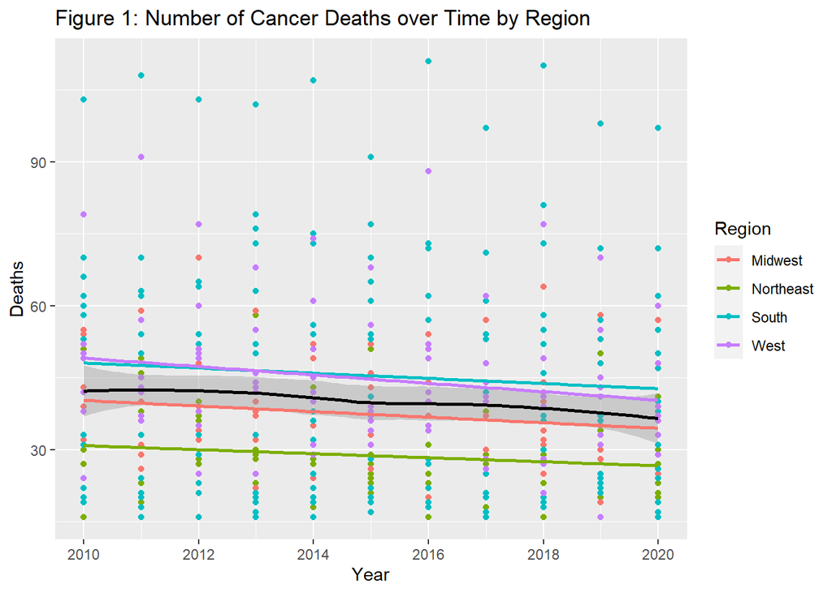

As we can see, it appears that the number of deaths over time has decreased slightly. Originally, a faceted line plot was considered to evaluate this data, but due to the variation of data points, the plot was difficult to interpret, so a scatterplot was chosen. Surprisingly, it appears that cancer deaths are more prevalent among children in the South and West than in the Midwest and Northeast. It is unclear whether this is simply due to the number of deaths reported to the CDC in those regions or the population size, or if there is some other factor, like a higher rate of genetic predispositions to cancer or a difference in the resources available for cancer treatment. Next, we wanted to re-evaluate this data using a bar-plot, but providing further evaluation by faceting by age group, as shown in Figure 2.

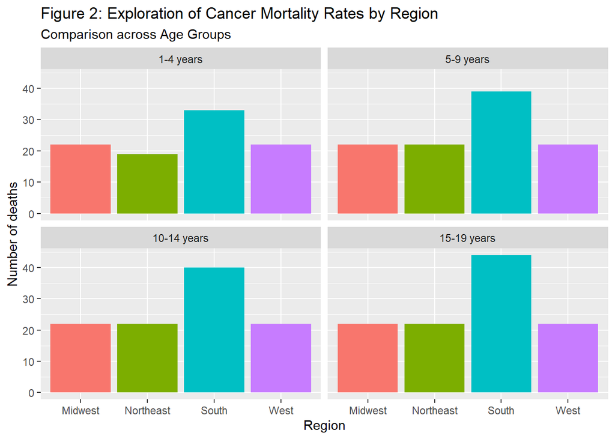

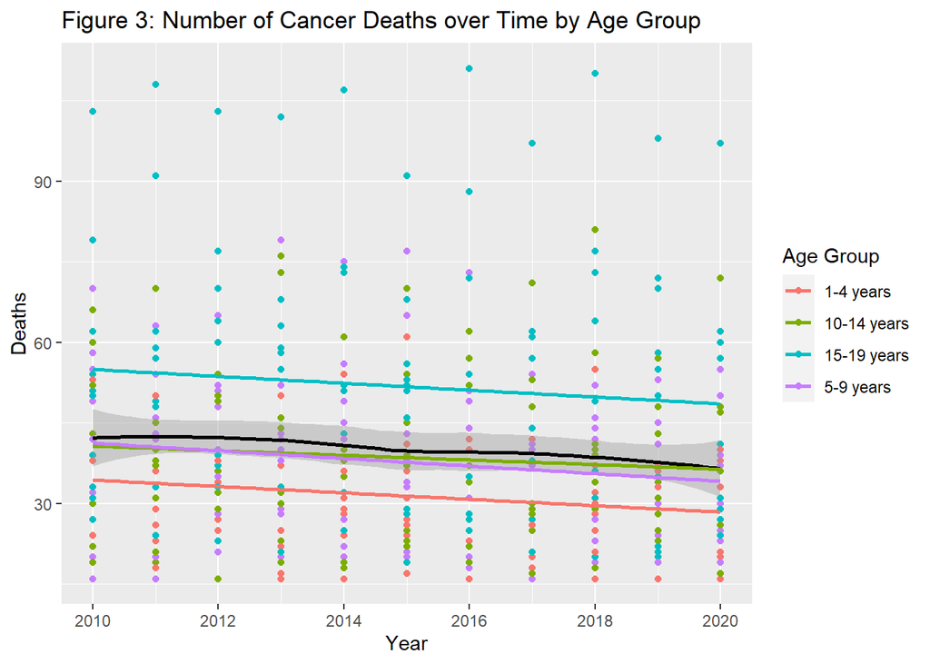

[figure not shown]

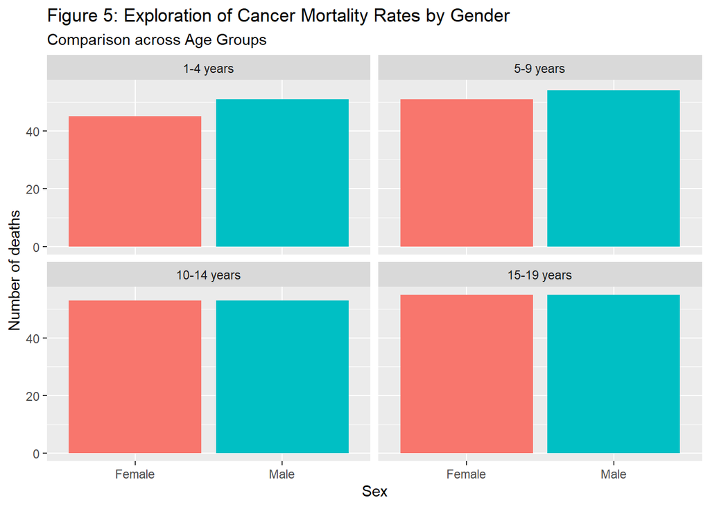

The figure above indicates that in both genders, the number of deaths increases as age increases. The difference between genders is less noticeable than in Figure 4.

The data collected thus far has been helpful, but it would be nice to summarize our findings in one plot that considers and displays all these factors. Fortunately, we can cross-classify data using the “facet_grid” function, as is done in Figure 6 below to neatly display our findings.

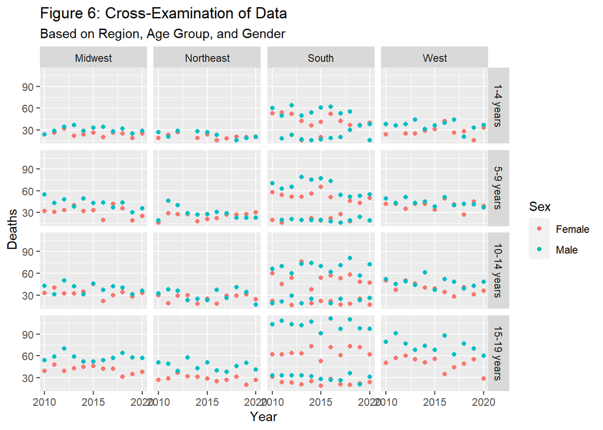

**Conclusion**

In conclusion, we have succeeded in the goal of this study by understanding how cancer deaths in children have changed over time and how they vary based on demographic factors. We were able to do this using data visualization methods.

Figures 1, 3, and 4 (and Figure 6 to a lesser scale) indicated a slight decrease in the total number of cancer deaths among children from 2010-2020. This is encouraging because countless amounts of funding, time and research have been put in by scientists and institutions, and it is reassuring to know the work is proving useful for children as well.

Demographically speaking, we noticed that the highest number of deaths occurs among children in the South, followed by the West. It is unclear whether this is due to a difference in the number of deaths reported or the population size, or if it has a scientific reason such as a lack of resources for cancer treatment or if there are genetic factors related to terminal cancers that are more present in certain regions. Further studies to examine this are encouraged. We also see that as age increases, the number of deaths increases, which we may have expected due to the increase in lifetime and thus increase in exposure to things such as carcinogens. Finally, we notice that females have less cancer deaths than males. This is significant as one might expect this to be equal, so it may mean that there are more genetic or hereditary cancers present in young males, or simply a higher ratio of terminal types of cancer. This should be studied further by scientists as well.

Regardless, we have confirmed that there are demographic factors related to the number of cancer deaths in children in the United States, and that the total number of these deaths has declined over time. We were able to clearly decipher this information using “ggplot2”, proving what a powerful tool it can be when used for data visualization.